# TITLE by Rodrigo P Maruyama

# Bivariate Plots Section

## GGPAIRS plot

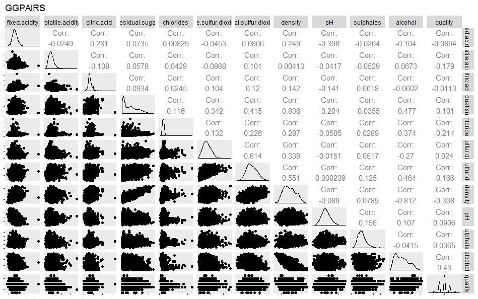

```r
ggpairs(wdf.outliers, title = 'GGPAIRS') +
  theme(panel.grid.minor = element_blank(), panel.grid.major = element_blank(),       axis.line=element_blank(), axis.text=element_blank())
```

With Ggpairs we can have a overview about the correlation for all dataset with scatter plot, density and correlation number.

## CORRPLOT

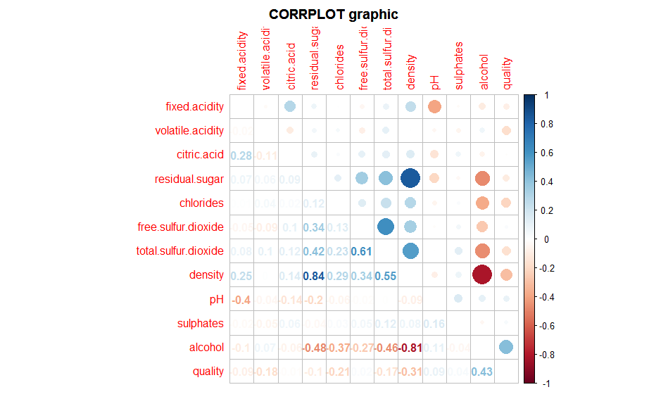

```r
cor.wdf.outliers <- cor(wdf.outliers)
corrplot.mixed(cor.wdf.outliers, tl.pos = 'lt', mar=c(2,0,2,0), title = 'CORRPLOT graphic')
```

Looking at the “ggpairs” and “corrplot” plots result it is easy to have a good idea about the correlations between the features. In the table below there is a list with a few pairs with a positive, negative and zero correlation. The positive correlation have 4 rows but we will discharge the number 2 because those features have similar properties.

## Positive, Negative and Zero Correlation Table

|  | Positive correlation | correlation |
| --- | --- | --- |
| 1 | density x residual.sugar | 0.84 |
| 2 | total.sulfur.dioxide x free.sulfur.dioxide | 0.61 |
| 3 | density x total.sulfur.dioxide | 0.55 |
| 4 | quality x alcohol | 0.42 |

|  | Negative correlation | correlation |
| --- | --- | --- |
| 1 | density x alcohol | -0.81 |
| 2 | alcohol x residual.sugar | -0.48 |
| 3 | total.sulfur.dioxide x alcohol | -0.46 |

|  | Zero correlation | correlation |
| --- | --- | --- |
| 1 | quality x citric.acid | 0.02 |
| 2 | sulphates x chlorides | 0.07 |
| 3 | density x volatily.acidity | 0.02 |

## Bivariate Boxplots

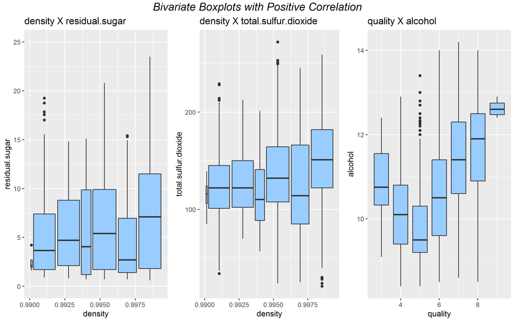

We can observe a very clear tendency for good wines to have a different behavior from the others.For example, in the 3rd plot (quality x alcohol) the good wines have a level of alcohol around 12 % volume, what means around 1% higher than the others as you can see below:

```r
paste('good:', mean.good,
  '% / normal:', mean.normal,
  '% / bad:', mean.bad, '%',
  sep = ' ')
```

[output not shown]

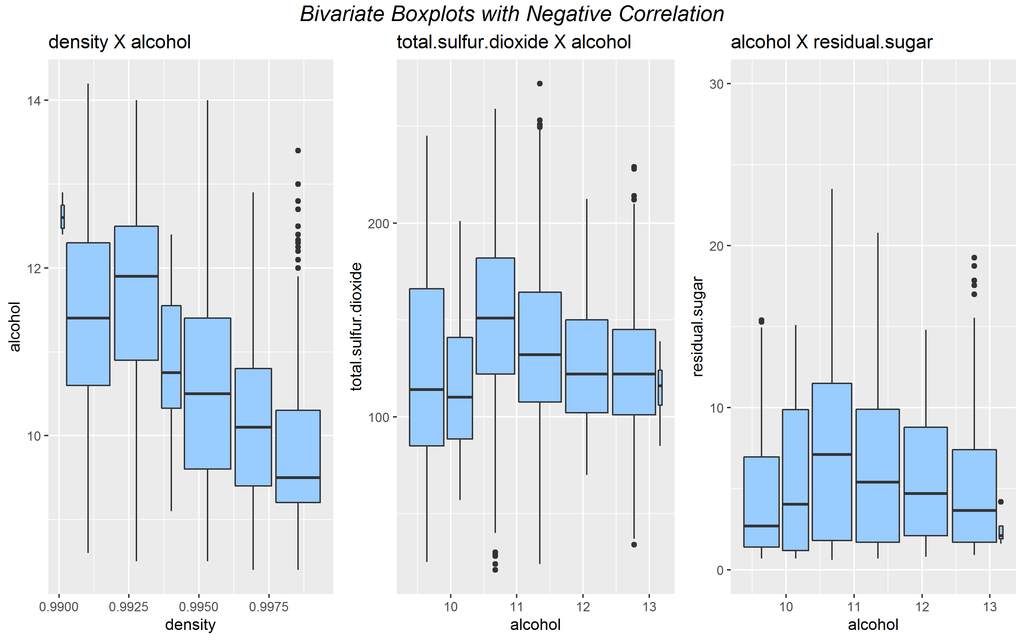

We can verify in the 1st plot that higher levels of density means low level of alcohol what it is expected once water is denser than alcohol.

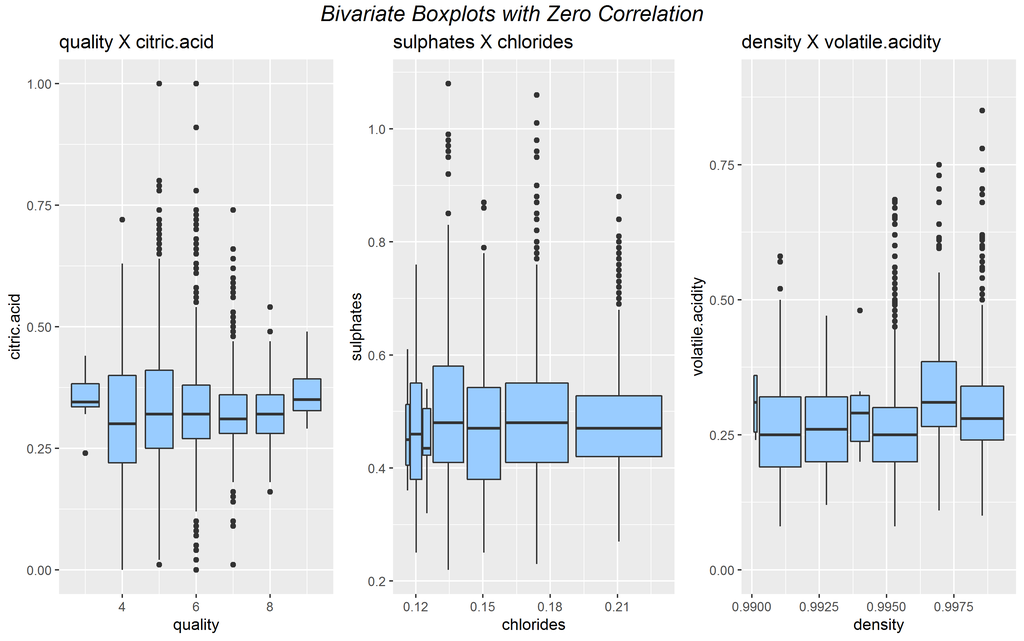

We can notice that we have much more outliers and a flat behavior for the features with zero correlation than the positive and negative ones.

## Bivariate Scatter plots with linear regression line

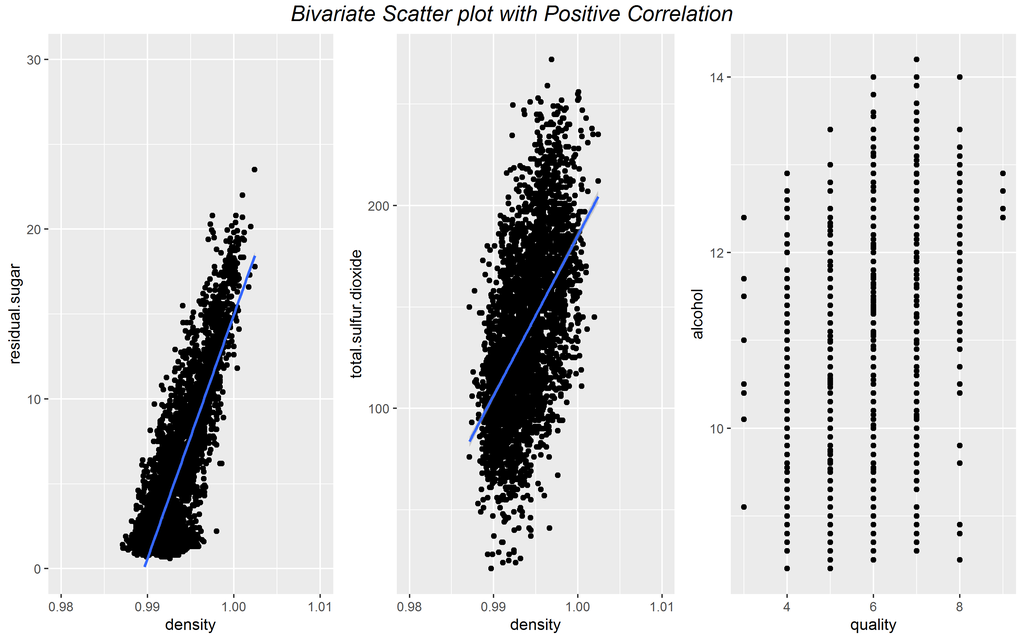

It is very clear to notice with the linear regression lines the positive correlation beteween those features once the x variable increase as the y variable increase too.

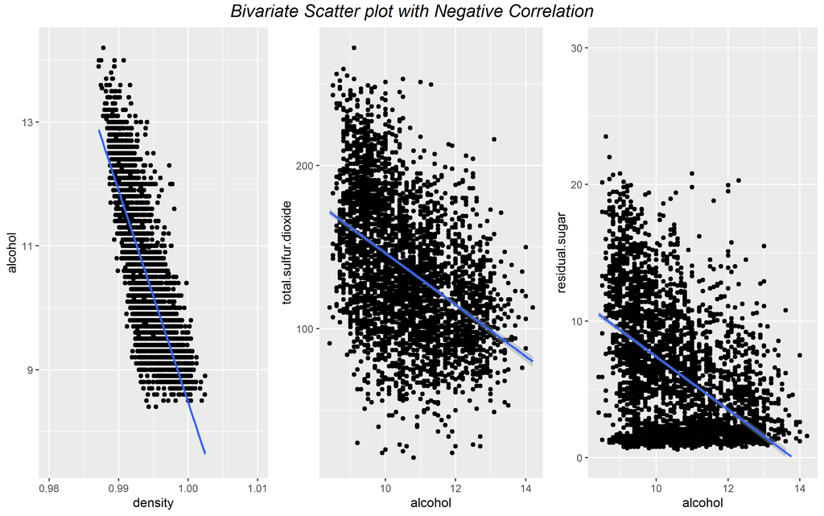

Similar to the positive correlation, here it is clear again the negative correlation looking for the linear regression lines.

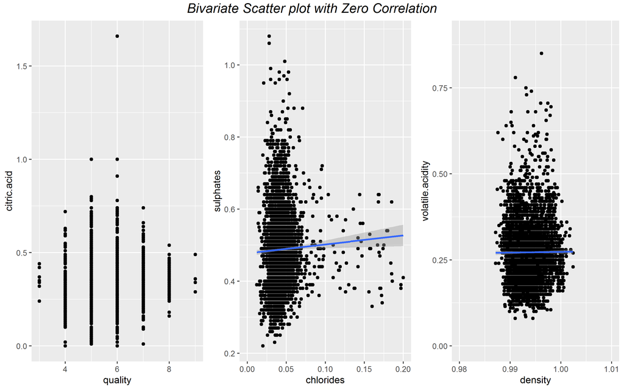

In this graphic it is interesting the 2nd plot where we have a very clear cluster on the left side and some points spread out on the right side. This can be a motivation to look into those ones carefully.

## Bivariate Analysis

### Talk about some of the relationships you observed in this part of the investigation. How did the feature(s) of interest vary with other features in the dataset?

- Strong Positive correlation

In the density_X_residual.sugar plot we can observe a strong correlation. The amount of wines with lower density and residual.sugar is bigger than high values. In density_X_total.sulfur.dioxide the plot have a eclipse format where the amount of wines have a concentration in the midle for both features but fot total.sulfur.dioxide they are spread much more.

- Strong Negative correlation

In the density_X_alcohol plot we can see the expected behavior once the alcohol density is lower than the water density. For both second and third plots they have a negative tendency nad for alcohol_X_residual.sugar they are a concentration of wines with lower residual.sugar quantities.

- Zero Correlation

Those plots we can check what was expected from the correlation value. They don't have any strong tendency.

### Did you observe any interesting relationships between the other features (not the main feature(s) of interest)?

No.

### What was the strongest relationship you found?

|  | Positive correlation | correlation |
| --- | --- | --- |
| 1 | density x residual.sugar | 0.84 |
| 2 | total.sulfur.dioxide x free.sulfur.dioxide | 0.61 |
| 3 | density x total.sulfur.dioxide | 0.55 |
| 4 | quality x alcohol | 0.42 |

# Multivariate Plots Section

## Highest Correlated features plots

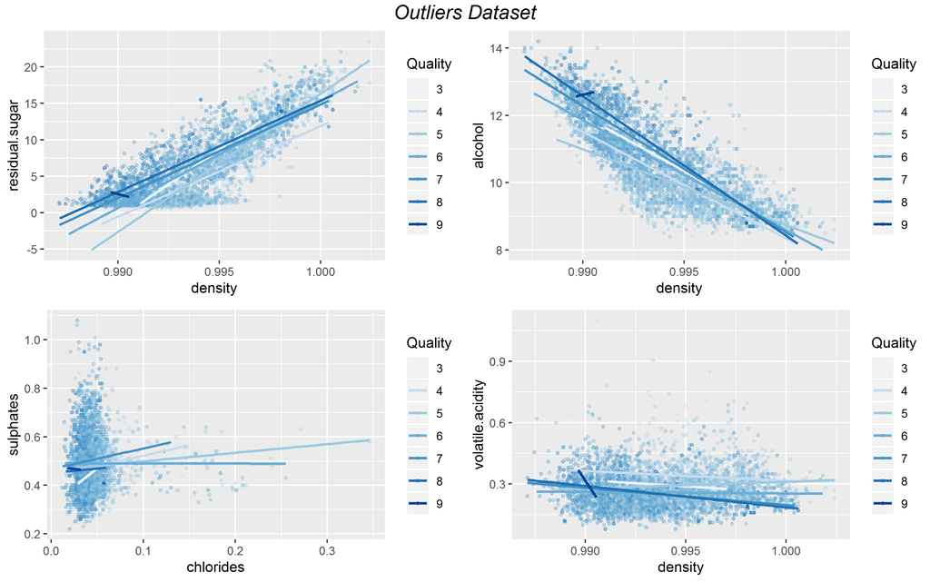

## Multivariate Analysis

### Talk about some of the relationships you observed in this part of the investigation. Were there features that strengthened each other in terms of looking at your feature(s) of interest?

We can confirm the correlation between density and residual.sugar in the ggpairs plot and linear regression line over the previous one. I all of the 4 multivariate graphics we can observe a concentration for good wines instead normal and bad ones.

# Machine Learning Models

## Creating Training and Test Datasets for Raw Data

```r
# Loading wdf.raw dataset
wdf.raw <- wdf
wdf.raw$X <- NULL
wdf.raw$quality <- as.factor(wdf$quality)

# Creating train.raw and test.raw datasets
set.seed(13)
samp <- sample(nrow(wdf.raw), 0.4 * nrow(wdf.raw))
train.raw <- wdf.raw[samp, ]
test.raw <- wdf.raw[-samp, ]
```

## Creating Training and Test Datasets for Outliers

```r
wdf.outliers$quality <- as.factor(wdf.outliers$quality)

# Creating Train.outliers and Test.outliers datasets
set.seed(13)
samp <- sample(nrow(wdf.outliers), 0.4 * nrow(wdf.outliers))
train.outliers <- wdf.outliers[samp, ]
test.outliers <- wdf.outliers[-samp, ]
```

## Random Forest Model

```r
# Random Forest Raw
a <- 0
while (a < 10){
  a <- a + 1
  model <- randomForest(quality ~ . - quality, data = train.raw)
  rf.pred <- predict(model, newdata = test.raw)
  acc.rf <- classAgreement(table(rf.pred, test.raw$quality))[1]
  time <- Sys.time()
  str <- paste('rf', time, as.numeric(acc.rf), sep = ',')
  write(str, file = 'data/accuracy_models.csv', append = TRUE)
}

# Random Forest Raw
a <- 0
while (a < 10){
  a <- a + 1
  model <- randomForest(quality ~ . - quality, data = train.outliers)
  rf.pred <- predict(model, newdata = test.outliers)
  acc.rf <- classAgreement(table(rf.pred, test.outliers$quality))[1]
  time <- Sys.time()
  str <- paste('rf.out', time, as.numeric(acc.rf), sep = ',')
  write(str, file = 'data/accuracy_models.csv', append = TRUE)
}
```

## Tuning the parameters SVM

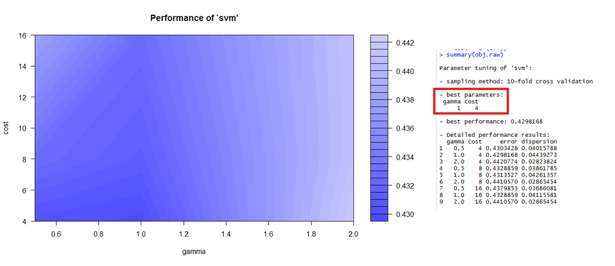

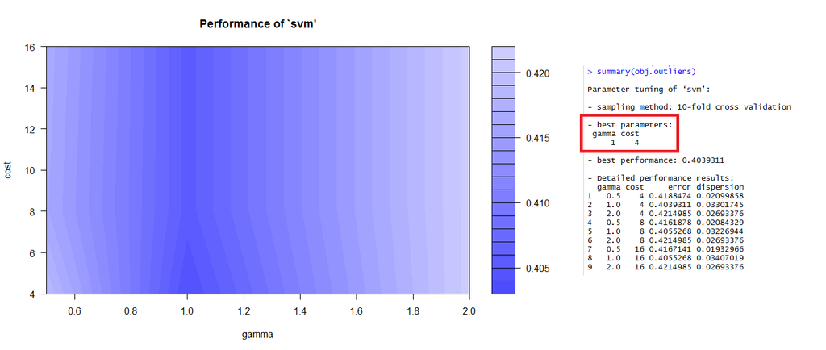

```r
# Tune with raw dataset
obj.raw <- tune.svm(quality~., data = train.raw, gamma = 2^(-1:1),
  cost = 2^(2:4))
summary(obj.raw)
p.tune.svm.raw <- (plot(obj.raw))

# tune with outliers dataset
obj.outliers <- tune.svm(quality~., data = train.outliers, gamma = 2^(-1:1),
  cost = 2^(2:4))
summary(obj.outliers)
p.tune.svm.outliers <- (plot(obj.outliers))
```

## Supported Vector Machines

```r
# SVM raw
df.list <- list(data.frame(train.raw), data.frame(test.raw))
a <- 0
while (a < 10){
  a <- a + 1
  svm.model  <- svm(quality ~ ., data = train.raw, cost = 4, gamma = 1)
  svm.pred <- predict(svm.model,test.raw[,-12])
  acc.svm <- classAgreement(table(svm.pred, test.raw$quality))[1]
  time <- Sys.time()
  str <- paste('svm', time, as.numeric(acc.svm), sep = ',')
  write(str, file = 'data/accuracy_models.csv', append = TRUE)
}

# SVM outliers
df.list <- list(data.frame(train.outliers), data.frame(test.outliers))
a <- 0
while (a < 10){
  a <- a + 1
  svm.model  <- svm(quality ~ ., data = train.outliers, cost = 4, gamma = 1)
  svm.pred <- predict(svm.model,test.outliers[,-12])
  acc.svm <- classAgreement(table(svm.pred, test.outliers$quality))[1]
  time <- Sys.time()
  str <- paste('svm.out', time, as.numeric(acc.svm), sep = ',')
  write(str, file = 'data/accuracy_models.csv', append = TRUE)
}
```

## Rpart

```r
# rpart raw
a <- 0
while (a < 10){
  a <- a + 1
  rpart.model <- rpart(quality ~ ., data = train.raw)
  rpart.pred <- predict(rpart.model, test.raw[,-12], type = 'class')
  table(rpart.pred,test.raw[,12])
  classAgreement(table(pred = rpart.pred,true = test.raw[,12]))
  acc.rpart <- classAgreement(table(rpart.pred, test.raw$quality))[1]
  time <- Sys.time()
  str <- paste('rpart', time, as.numeric(acc.rpart), sep = ',')
  write(str, file = 'data/accuracy_models.csv', append = TRUE)
}

# rpart outliers
a <- 0
while (a < 10){
  a <- a + 1
  rpart.model <- rpart(quality ~ ., data = train.outliers)
  rpart.pred <- predict(rpart.model, test.outliers[,-12], type = 'class')
  table(rpart.pred,test.outliers[,12])
  classAgreement(table(pred = rpart.pred,true = test.outliers[,12]))
  acc.rpart <- classAgreement(table(rpart.pred, test.outliers$quality))[1]
  time <- Sys.time()
  str <- paste('rpart.out', time, as.numeric(acc.rpart), sep = ',')
  write(str, file = 'data/accuracy_models.csv', append = TRUE)
}
```

## The Accuracy average for each Model

```r
htmlTable(acc.matrix,
          css.cell = ("padding-left: 1em; padding-right: 1em;"),
          header =  c('Random Forest', 'SVM', 'Rpart'),
          rnames = c('RAW Data', 'Outliers Data'),
          caption="Accuracy Mean (%)")
```

[output not shown]

## Pricipal component analysis - PCA

To better understand how the features are correlated I ran a PCA algorithm and I did the plot for the PCA Components and a graphic with Variance x Number of Component to decide how many Components I will use in the following models.

```r
# PCA
wdf.pca <- prcomp(wdf.outliers[,1:11], center = TRUE, scale. = TRUE)
```

### Variance x Number of components

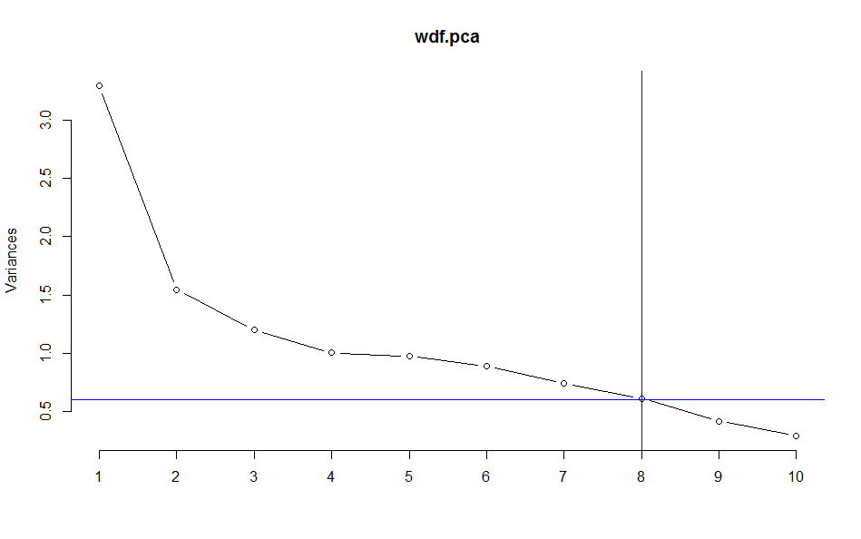

Looking at this graphic it is easy to indentify that we can run the models with 8 components without loosing accuracy in our model.

### Correlation between features

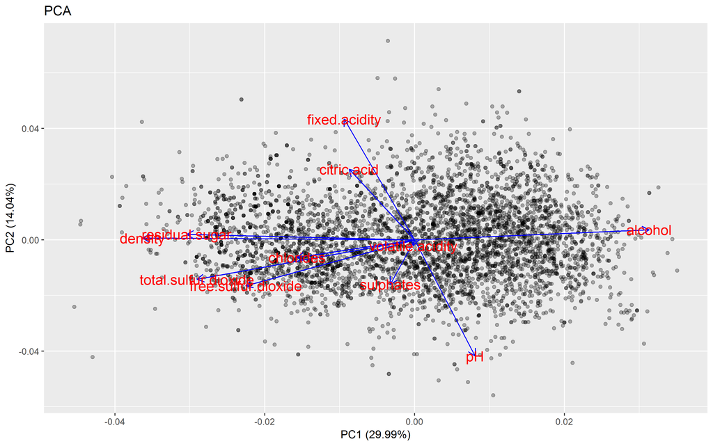

In this graphic we can confirm some teories about the correlation between the variables. For example we expect negative correlation with alcohol and residual.sugar once the alcohol needs sugar to be produced. pH and citric.acid and fixed.acidity also need to have negative correlation once the lowest pH means very acid solution.

## New PCA Datasets

```r
# New dataframe
new.wdf.pca <- data.frame(wdf.pca$x)
new.wdf.pca <- data.frame(new.wdf.pca[,1:8], quality = wdf.outliers$quality)

# Creating train and test datasets
set.seed(123)
samp <- sample(nrow(new.wdf.pca), 0.8 * nrow(new.wdf.pca))
new.train.pca <- new.wdf.pca[samp, ]
new.test.pca <- new.wdf.pca[-samp, ]
```

## Random Forest Model after PCA

```r
# Random Forest Raw
a <- 0
while (a < 10){
  a <- a + 1
  model <- randomForest(quality ~ . - quality, data = new.train.pca)
  rf.pred <- predict(model, newdata = new.test.pca[, -9])
  acc.rf <- classAgreement(table(rf.pred, new.test.pca$quality))[1]
  time <- Sys.time()
  str <- paste('rf', time, as.numeric(acc.rf), sep = ',')
  write(str, file = 'data/accuracy_models_pca.csv', append = TRUE)
}
```

## Mean Random Forest Accuracy

```r
htmlTable(mean.acc.rf,
          css.cell = ("padding-left: 1em; padding-right: 1em;"),
          header =  c('Random Forest'),
          rnames = c('Outliers Data'),
          caption="Accuracy Mean (%)")
```

| Accuracy Mean (%) | Accuracy Mean (%) Random Forest |
| --- | --- |
| Outliers Data | 69.11 |

# Final Plots and Summary

## Plot One

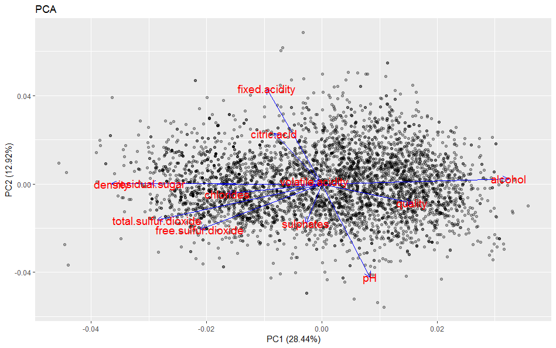

## Plot Two

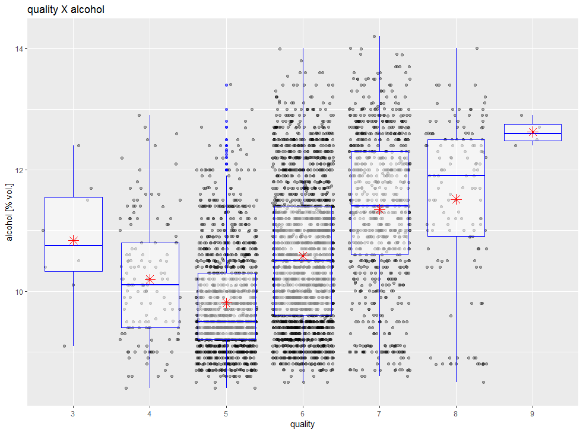

### Description Two

In this Graphic we can see that the Very Good wines (quality = 9) have a very low variance. If we look the Median lines for each class (Good, Normal, Bad) we can see that the main Wine Qualities are 5, 6 and 7 because those lines are matching with their respective Medians. This is just another way we saw in the Density graphics where we plot the Mean and Median over the distribution for each feature.

## Plot Three

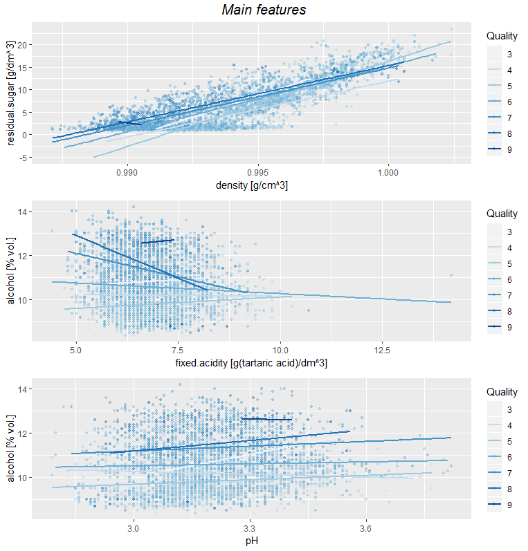

### Description Three

In this plot, I want to see the correlations I expected observe following the wine specialists, acidity, sweetness and alcohol. However, we can see a very strong correlation between sweetness and density. For the other 2 characteristics, the points are very spread out.

# Reflection

# General resources

## Articles

- Modeling wine preferences by data mining from physicochemical properties by Paulo Cortez,Ant?nio Cerdeira, Fernando Almeida, Telmo Matos, Jos? Reis. (2009) 547-553
- Support Vector Machines, The Interface to libsvm in package e1071 by David Meyer
- A Practical Guide to Support Vector Classification by Chih-Wei Hsu, Chih-Chung Chang, and Chih-Jen Lin (2016)

## R

Remove the column X from Dataframe: https://stackoverflow.com/questions/6286313/remove-an-entire-column-from-a-data-frame-in-r/30620946  
Write function: https://stat.ethz.ch/R-manual/R-devel/library/base/html/write.html  
Get current Date and Time: https://stat.ethz.ch/R-manual/R-devel/library/base/html/Sys.time.html  
Concatenate Strings: https://stat.ethz.ch/R-manual/R-devel/library/base/html/paste.html  
Format function: https://www.rdocumentation.org/packages/base/versions/3.5.1/topics/format  
htmlTable: https://cran.r-project.org/web/packages/htmlTable/vignettes/tables.html  
ROCR: https://cran.r-project.org/web/packages/ROCR/ROCR.pdf  
anti_join: https://stackoverflow.com/questions/38085288/how-to-subtract-one-dataframe-from-another

## Style and Markdown tools and cheatsheet

Marktable generator: https://www.tablesgenerator.com/markdown_tables  
markdown table formater: http://markdowntable.com/  
Markdown basics: https://rmarkdown.rstudio.com/authoring_basics.html  
Style guide: http://adv-r.had.co.nz/Style.html  
Histogram colors: https://www.r-bloggers.com/how-to-make-a-histogram-with-ggplot2/

## Wine related articles

Sulfite regulation USA: https://www.ecfr.gov/cgi-bin/text-idx?c=ecfr&sid=33fc0c0194b58b6fe95208945b5c637a&rgn=div5&view=text&node=27:1.0.1.1.2&idno=27  
Wine Characteristics: https://winefolly.com/review/wine-characteristics/

## GGplot, GGPAIRS, Corrplot and other Visualizations tips and tricks

Colors in ggplot: http://www.cookbook-r.com/Graphs/Colors_(ggplot2)/  
More COlors in ggplot: http://www.sthda.com/english/wiki/ggplot2-colors-how-to-change-colors-automatically-and-manually  
Insert a line in plot: http://www.sthda.com/english/wiki/abline-r-function-an-easy-way-to-add-straight-lines-to-a-plot-using-r-software  
Corrplot: https://cran.r-project.org/web/packages/corrplot/vignettes/corrplot-intro.html  
aes_string in the geom_vline: https://www.biostars.org/p/234142/  
Pie color reference link: http://www.r-tutor.com/elementary-statistics/qualitative-data/pie-chart  
Legend and percent reference link: https://www.tutorialspoint.com/r/r_pie_charts.htm  
GGpairs: https://www.rdocumentation.org/packages/GGally/versions/1.4.0/topics/ggpairs  
Ggpairs with background: https://stackoverflow.com/questions/48104455/ggpairs-correlation-values-without-gridlines  
ggbipplot documentation: https://www.rdocumentation.org/packages/ggbiplot/versions/0.55

## PCA and Machine Learning Models

PCA: https://www.r-bloggers.com/computing-and-visualizing-pca-in-r/  
Random Forest Predictor: https://datascienceplus.com/predicting-wine-quality-using-random-forests/  
Random Forest + PCA: https://www.analyticsvidhya.com/blog/2016/03/practical-guide-principal-component-analysis-python/